# Practical Machine Learning Course Project

Linda Zahora-Cathcart

10/18/2019

### BACKGROUND

One thing that people regularly do is quantify how much of a particular activity they do, but they rarely quantify how well they do it. In this project, the goal will be to use data from accelerometers on the belt, forearm, arm, and dumbell of 6 participants. They were asked to perform barbell lifts correctly and incorrectly in 5 different ways.

Data comes courtesy of “Ugulino, W.; Cardador, D.; Vega, K.; Velloso, E.; Milidiu, R.; Fuks, H. Wearable Computing: Accelerometers’ Data Classification of Body Postures and Movements”.

More information is available here: http://web.archive.org/web/20161224072740/http:/groupware.les.inf.puc-rio.br/har

### OVERVIEW

In this project we will predict the manner in which the participants exercised (the “classe” variable in the training set). Requirements for submission:

- A report describing how you built your models
- How you used cross validation
- Expected out of sample error is
- Why you made the choices you did
- Use your prediction model to predict 20 different test cases.

### LOAD LIBRARIES

```r
library(caret)
```

```r
library(corrplot)
library(e1071)
library(randomForest)
```

### LOAD TRAINING DATA

```r
# load the training data into RStudio
train <- read.csv("pml-training.csv")

# explore your training data
str(train)
```

```
## 'data.frame':    19622 obs. of  160 variables:
##  $ X                       : int  1 2 3 4 5 6 7 8 9 10 ...
##  $ user_name               : Factor w/ 6 levels "adelmo","carlitos",..: 2 2 2 2 2 2 2 2 2 2 ...
##  $ raw_timestamp_part_1    : int  1323084231 1323084231 1323084231 1323084232 1323084232 1323084232 1323084232 1323084232 1323084232 1323084232 ...
##  $ raw_timestamp_part_2    : int  788290 808298 820366 120339 196328 304277 368296 440390 484323 484434 ...
##  $ cvtd_timestamp          : Factor w/ 20 levels "02/12/2011 13:32",..: 9 9 9 9 9 9 9 9 9 9 ...
##  $ new_window              : Factor w/ 2 levels "no","yes": 1 1 1 1 1 1 1 1 1 1 ...
##  $ num_window              : int  11 11 11 12 12 12 12 12 12 12 ...
##  $ roll_belt               : num  1.41 1.41 1.42 1.48 1.48 1.45 1.42 1.42 1.43 1.45 ...
##  $ pitch_belt              : num  8.07 8.07 8.07 8.05 8.07 8.06 8.09 8.13 8.16 8.17 ...
##  $ yaw_belt                : num  -94.4 -94.4 -94.4 -94.4 -94.4 -94.4 -94.4 -94.4 -94.4 -94.4 ...
##  $ total_accel_belt        : int  3 3 3 3 3 3 3 3 3 3 ...
##  $ kurtosis_roll_belt      : Factor w/ 397 levels "","-0.016850",..: 1 1 1 1 1 1 1 1 1 1 ...
##  $ kurtosis_picth_belt     : Factor w/ 317 levels "","-0.021887",..: 1 1 1 1 1 1 1 1 1 1 ...
##  $ kurtosis_yaw_belt       : Factor w/ 2 levels "","#DIV/0!": 1 1 1 1 1 1 1 1 1 1 ...
```

[output cut: 86 more lines]

```r
dim(train)
```

```
## [1] 19622   160
```

### LOAD TESTING DATA

```r
# load the testing data into RStudio
test <- read.csv("pml-testing.csv")

# explore your testing data
head(test)
```

```
##   X user_name raw_timestamp_part_1 raw_timestamp_part_2   cvtd_timestamp
## 1 1     pedro           1323095002               868349 05/12/2011 14:23
## 2 2    jeremy           1322673067               778725 30/11/2011 17:11
## 3 3    jeremy           1322673075               342967 30/11/2011 17:11
## 4 4    adelmo           1322832789               560311 02/12/2011 13:33
## 5 5    eurico           1322489635               814776 28/11/2011 14:13
## 6 6    jeremy           1322673149               510661 30/11/2011 17:12
##   new_window num_window roll_belt pitch_belt yaw_belt total_accel_belt
## 1         no         74    123.00      27.00    -4.75               20
## 2         no        431      1.02       4.87   -88.90                4
## 3         no        439      0.87       1.82   -88.50                5
## 4         no        194    125.00     -41.60   162.00               17
## 5         no        235      1.35       3.33   -88.60                3
## 6         no        504     -5.92       1.59   -87.70                4
##   kurtosis_roll_belt kurtosis_picth_belt kurtosis_yaw_belt
```

[output cut: 265 more lines]

```r
dim(test)
```

```
## [1]  20 160
```

After viewing our training set we found that it contains 19,622 observations with 160 variables, and many of these columns contain blank or NA values. The testing set contains 20 observations and 160 variables along with blank or NA values. Before we can move further we will need to remove the blank or NA columns as well as the first seven columns since they aren’t need for our model and analysis.

### CLEANING THE DATA

```r
# TRAINING DATA
# set all blank cells to NA's
train[train==""] <- NA
# remove all columns with NA's
train1 <- train[, colSums(is.na(train)) == 0]
# remove first 7 columns
train2 <- train1[,-c(1:7)]
# check dataset
dim(train2)
```

```
## [1] 19622    53
```

```r
# TESTING DATA
# set all blank cells to NA's
test[test==""] <- NA
# remove all columns with NA's
test1 <- test[, colSums(is.na(test)) == 0]
# remove first 7 columns
test2 <- test1[,-c(1:7)]
# check dataset
dim(test2)
```

```
## [1] 20 53
```

### DATA SPLITTING

Next, we’ll partition our training set to begin our model testing. We’ll use 75% of the train2$classe for training and 25% will be used for testing.

```r
# set your seed
set.seed(1011)

inTrain <-createDataPartition(train2$classe, p=0.75, list=FALSE)

TRAIN <- train2[inTrain,]
dim(TRAIN)
```

```
## [1] 14718    53
```

```r
TEST <- train2[-inTrain,]
dim(TEST)
```

```
## [1] 4904   53
```

### DISTRIBUTION

In order to get a better idea of what to expect for our model predictions let’s look at the current distribution for TRAIN$classe.

```r
# summarize distribution
distribution <- prop.table(table(TRAIN$classe)) * 100
cbind(freq=table(TRAIN$classe), percentage=distribution)
```

```
##   freq percentage
## A 4185   28.43457
## B 2848   19.35046
## C 2567   17.44123
## D 2412   16.38810
## E 2706   18.38565
```

### CORRELATION

Below you will find a correlation plot for the “TRAIN” training set., and the best correlations are in the darker shades of color.

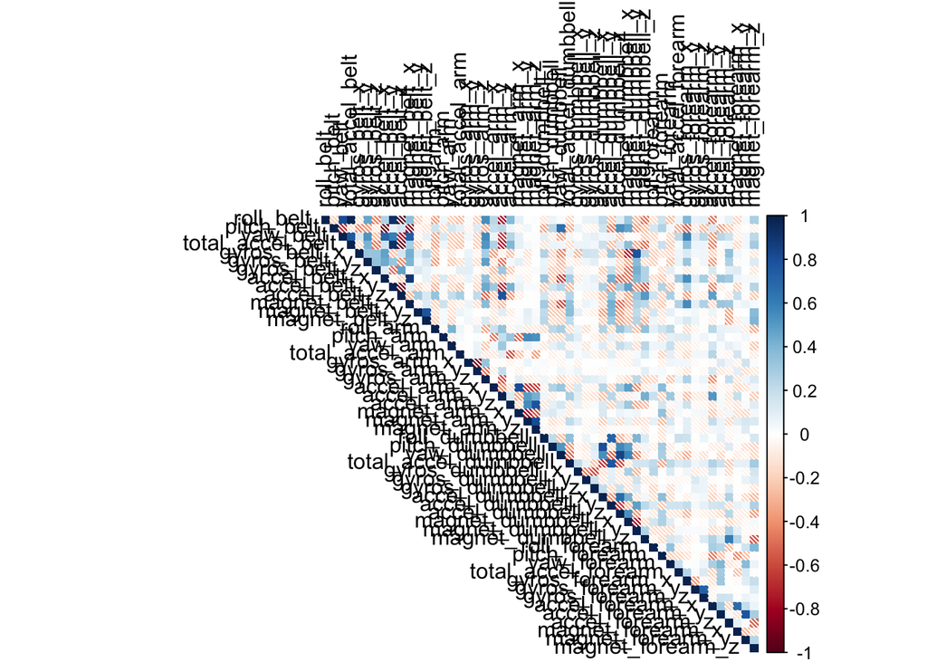

```r
corTRAIN <- cor(TRAIN[, -53])
corrplot(corTRAIN, type = "upper", method = "shade", tl.col="black")
```

Since there are numerous variables it’s hard to read this plot. With that being said, the best way to see variable correlation is with the following function:

```r
correlatedvariables = findCorrelation(corTRAIN, cutoff=0.75)
names(TRAIN)[correlatedvariables]
```

```
##  [1] "accel_belt_z"      "roll_belt"         "accel_arm_y"
##  [4] "accel_belt_y"      "total_accel_belt"  "accel_dumbbell_z"
##  [7] "accel_belt_x"      "pitch_belt"        "magnet_dumbbell_x"
## [10] "accel_dumbbell_y"  "magnet_dumbbell_y" "accel_dumbbell_x"
## [13] "accel_arm_x"       "accel_arm_z"       "magnet_arm_y"
## [16] "magnet_belt_z"     "accel_forearm_y"   "gyros_arm_x"
```

This information will give us a good idea on how the variables will interact with each other when applied to our models.

### CROSS VALIDATION

Next, we’ll use a 10-fold cross validation to estimate accuracy for each of our algorithms.

```r
# run the algorithms using the 10-fold cross validation
control <- trainControl(method="cv", number=10)
metric <- "Accuracy"
```

### MODEL BUILDING

We’ll be using three different models to predict the outcome. They are: * Linear Discriminant Analysis (LDA) * Classification and Regression Trees (CART) * Random Forest (RF)

These models were selected to give a good mixture of simple linear (LDA), nonlinear (CART) and complex nonlinear methods (RF).

#### Prediction with Linear Discriminant Analysis

```r
set.seed(1011)
fit.lda <- train(classe~., data=TRAIN, method="lda", metric=metric, trControl=control)
print(fit.lda)
```

```
## Linear Discriminant Analysis
##
## 14718 samples
##    52 predictor
##     5 classes: 'A', 'B', 'C', 'D', 'E'
##
## No pre-processing
## Resampling: Cross-Validated (10 fold)
## Summary of sample sizes: 13249, 13246, 13247, 13247, 13245, 13247, ...
## Resampling results:
##
##   Accuracy   Kappa
##   0.7026103  0.6235749
```

```r
# validate model
predictLDA <- predict(fit.lda, newdata=TEST)

# confusion matrix
confuseLDA <- confusionMatrix(TEST$classe, predictLDA)
print(confuseLDA)
```

```
## Confusion Matrix and Statistics
##
##           Reference
## Prediction    A    B    C    D    E
##          A 1141   30  108  110    6
##          B  136  617  105   44   47
##          C   82   79  569  105   20
##          D   48   30   91  603   32
##          E   27  168   78   97  531
##
## Overall Statistics
##
##                Accuracy : 0.7058
##                  95% CI : (0.6928, 0.7185)
##     No Information Rate : 0.2924
##     P-Value [Acc > NIR] : < 2.2e-16
##
##                   Kappa : 0.6278
##
##  Mcnemar's Test P-Value : < 2.2e-16
##
## Statistics by Class:
##
##                      Class: A Class: B Class: C Class: D Class: E
## Sensitivity            0.7957   0.6677   0.5983   0.6288   0.8349
## Specificity            0.9268   0.9166   0.9276   0.9490   0.9133
## Pos Pred Value         0.8179   0.6502   0.6655   0.7500   0.5893
## Neg Pred Value         0.9165   0.9224   0.9057   0.9132   0.9738
## Prevalence             0.2924   0.1884   0.1939   0.1956   0.1297
## Detection Rate         0.2327   0.1258   0.1160   0.1230   0.1083
## Detection Prevalence   0.2845   0.1935   0.1743   0.1639   0.1837
## Balanced Accuracy      0.8612   0.7922   0.7630   0.7889   0.8741
```

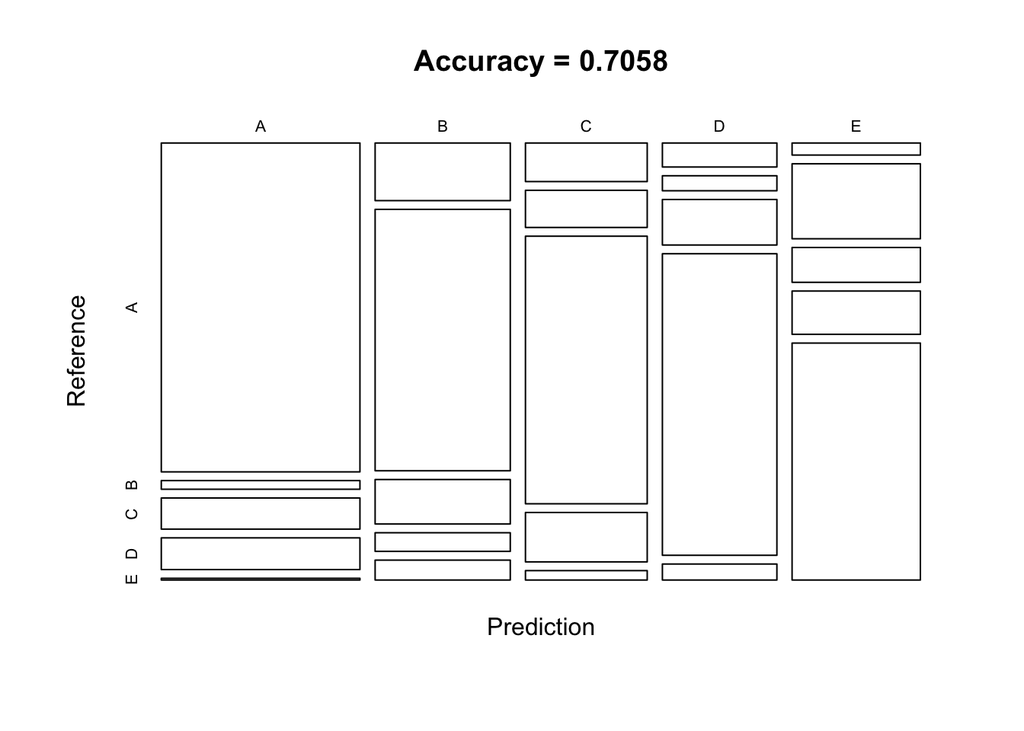

```r
# plot confusion matrix
plot(confuseLDA$table, col = confuseLDA$byClass,
      main = paste("Accuracy =", round(confuseLDA$overall['Accuracy'], 4)))
```

As you can see from our confusion matrix our first model’s accuracy is 70% so our out-of-sample-error would be 0.3 which isn’t favorable.

#### Prediction with Classification and Regression Trees

```r
set.seed(1011)
fit.cart <- train(classe~., data=TRAIN, method="rpart", metric=metric, trControl=control)
print(fit.cart)
```

```
## CART
##
## 14718 samples
##    52 predictor
##     5 classes: 'A', 'B', 'C', 'D', 'E'
##
## No pre-processing
## Resampling: Cross-Validated (10 fold)
## Summary of sample sizes: 13249, 13246, 13247, 13247, 13245, 13247, ...
## Resampling results across tuning parameters:
##
##   cp          Accuracy   Kappa
##   0.03693155  0.5027241  0.3508133
##   0.05933732  0.4409900  0.2506677
##   0.11706067  0.3329472  0.0741510
##
## Accuracy was used to select the optimal model using the largest value.
## The final value used for the model was cp = 0.03693155.
```

```r
# validate model
predictCART <- predict(fit.cart, newdata=TEST)

# confusion matrix
confuseCART <- confusionMatrix(TEST$classe, predictCART)
print(confuseCART)
```

```
## Confusion Matrix and Statistics
##
##           Reference
## Prediction    A    B    C    D    E
##          A 1265   28   96    0    6
##          B  384  338  227    0    0
##          C  395   24  436    0    0
##          D  371  139  294    0    0
##          E  134  130  247    0  390
##
## Overall Statistics
##
##                Accuracy : 0.4953
##                  95% CI : (0.4812, 0.5094)
##     No Information Rate : 0.5198
##     P-Value [Acc > NIR] : 0.9997
##
##                   Kappa : 0.3403
##
##  Mcnemar's Test P-Value : NA
##
## Statistics by Class:
##
##                      Class: A Class: B Class: C Class: D Class: E
## Sensitivity            0.4963  0.51290  0.33538       NA  0.98485
## Specificity            0.9448  0.85607  0.88374   0.8361  0.88665
## Pos Pred Value         0.9068  0.35616  0.50994       NA  0.43285
## Neg Pred Value         0.6341  0.91884  0.78661       NA  0.99850
## Prevalence             0.5198  0.13438  0.26509   0.0000  0.08075
## Detection Rate         0.2580  0.06892  0.08891   0.0000  0.07953
## Detection Prevalence   0.2845  0.19352  0.17435   0.1639  0.18373
## Balanced Accuracy      0.7205  0.68448  0.60956       NA  0.93575
```

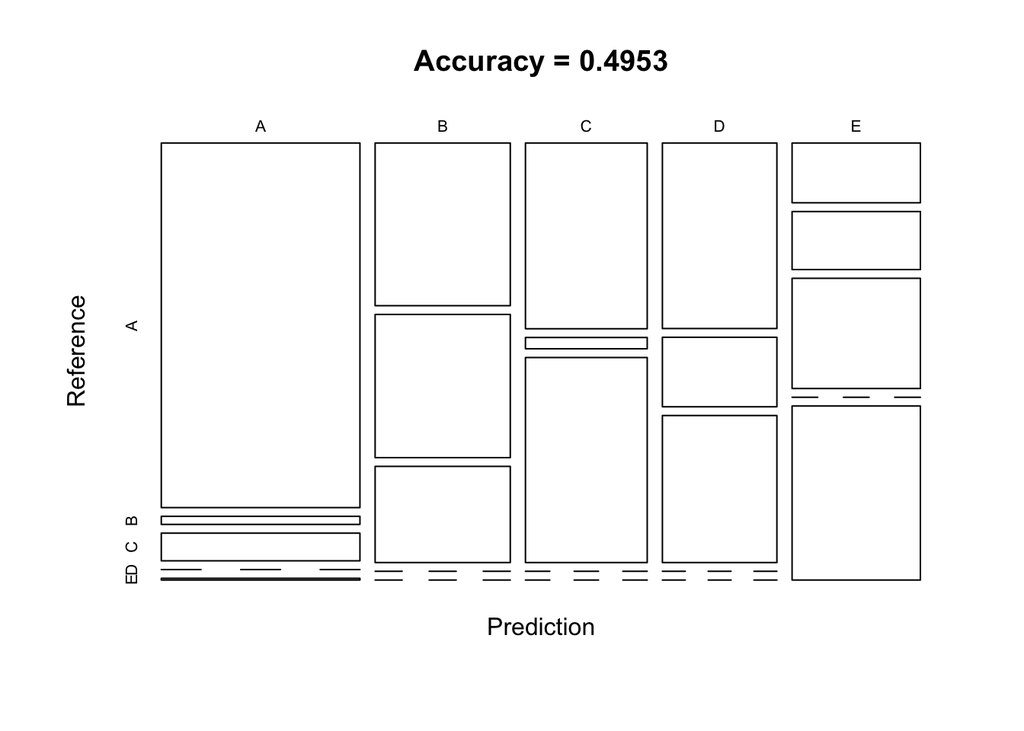

```r
# plot confusion matrix
plot(confuseCART$table, col = confuseCART$byClass,
      main = paste("Accuracy =", round(confuseCART$overall['Accuracy'], 4)))
```

Next, we ran our CART Model and it predicted with a significantly lower accuracy than our first. Our confusion matrix revealed that accuracy is just under 50% thus giving us an out-of-sample-error of just over 0.5.

#### Prediction with Random Forest

```r
set.seed(1011)
fit.rf <- train(classe~., data=TRAIN, method="rf", metric=metric, trControl=control)
print(fit.rf)
```

```
## Random Forest
##
## 14718 samples
##    52 predictor
##     5 classes: 'A', 'B', 'C', 'D', 'E'
##
## No pre-processing
## Resampling: Cross-Validated (10 fold)
## Summary of sample sizes: 13249, 13246, 13247, 13247, 13245, 13247, ...
## Resampling results across tuning parameters:
##
##   mtry  Accuracy   Kappa
##    2    0.9923907  0.9903740
##   27    0.9926624  0.9907175
##   52    0.9876348  0.9843568
##
## Accuracy was used to select the optimal model using the largest value.
## The final value used for the model was mtry = 27.
```

```r
# validate model
predictRF <- predict(fit.rf, newdata=TEST)

# confusion matrix
confuseRF <- confusionMatrix(TEST$classe, predictRF)
print(confuseRF)
```

```
## Confusion Matrix and Statistics
##
##           Reference
## Prediction    A    B    C    D    E
##          A 1393    1    0    0    1
##          B    4  943    2    0    0
##          C    0    3  850    2    0
##          D    0    0    9  795    0
##          E    0    0    1    0  900
##
## Overall Statistics
##
##                Accuracy : 0.9953
##                  95% CI : (0.993, 0.997)
##     No Information Rate : 0.2849
##     P-Value [Acc > NIR] : < 2.2e-16
##
##                   Kappa : 0.9941
##
##  Mcnemar's Test P-Value : NA
##
## Statistics by Class:
##
##                      Class: A Class: B Class: C Class: D Class: E
## Sensitivity            0.9971   0.9958   0.9861   0.9975   0.9989
## Specificity            0.9994   0.9985   0.9988   0.9978   0.9998
## Pos Pred Value         0.9986   0.9937   0.9942   0.9888   0.9989
## Neg Pred Value         0.9989   0.9990   0.9970   0.9995   0.9998
## Prevalence             0.2849   0.1931   0.1758   0.1625   0.1837
## Detection Rate         0.2841   0.1923   0.1733   0.1621   0.1835
## Detection Prevalence   0.2845   0.1935   0.1743   0.1639   0.1837
## Balanced Accuracy      0.9983   0.9971   0.9924   0.9976   0.9993
```

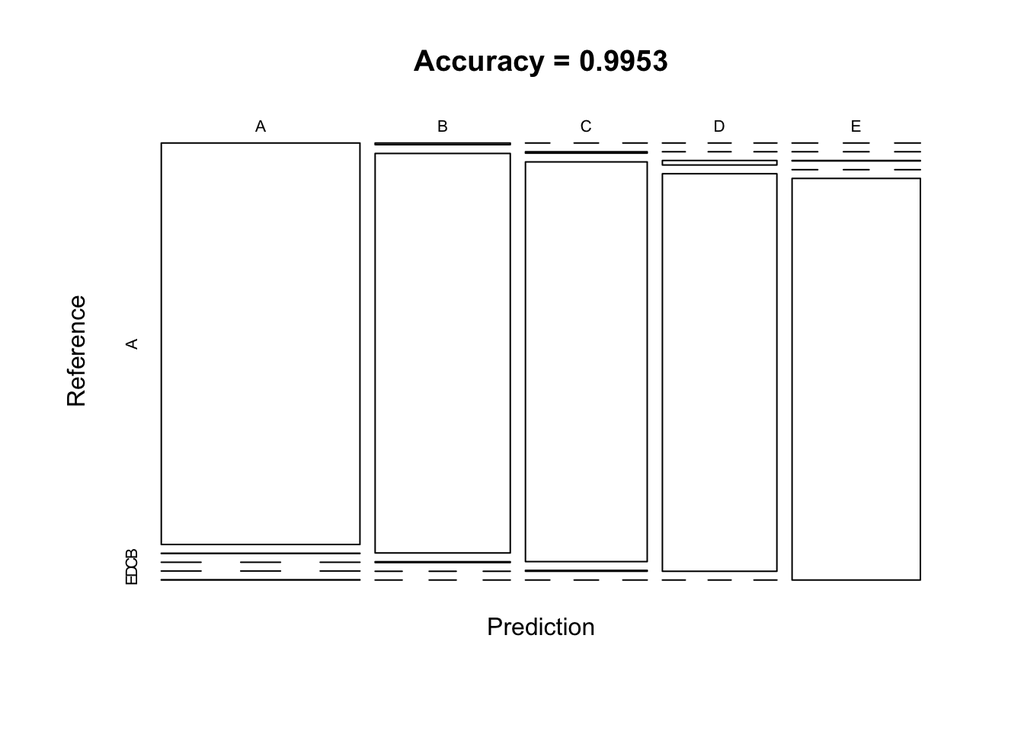

```r
# plot confusion matrix
plot(confuseRF$table, col = confuseRF$byClass,
      main = paste("Accuracy =", round(confuseRF$overall['Accuracy'], 4)))
```

```r
names(fit.rf$finalModel)
```

```
##  [1] "call"            "type"            "predicted"
##  [4] "err.rate"        "confusion"       "votes"
##  [7] "oob.times"       "classes"         "importance"
## [10] "importanceSD"    "localImportance" "proximity"
## [13] "ntree"           "mtry"            "forest"
## [16] "y"               "test"            "inbag"
## [19] "xNames"          "problemType"     "tuneValue"
## [22] "obsLevels"       "param"
```

Last, our Random Forest model, turned out well. Our confusion matrix shows that the accuracy is over 99% giving us our out-of-sample-error to be <0.1.

### Summarize Accuracy of Models

For a great comparison of all of our models we’ll use a table summary.

```r
#combine models into a list
results <- resamples(list(lda=fit.lda, cart=fit.cart, rf=fit.rf))
summary(results)
```

```
##
## Call:
## summary.resamples(object = results)
##
## Models: lda, cart, rf
## Number of resamples: 10
##
## Accuracy
##           Min.   1st Qu.    Median      Mean   3rd Qu.      Max. NA's
## lda  0.6861413 0.6979109 0.7029232 0.7026103 0.7065336 0.7250509    0
## cart 0.4833673 0.4907489 0.4977897 0.5027241 0.5115471 0.5350102    0
## rf   0.9904891 0.9918478 0.9925304 0.9926624 0.9937078 0.9945615    0
##
## Kappa
##           Min.   1st Qu.    Median      Mean   3rd Qu.      Max. NA's
## lda  0.6027018 0.6181883 0.6238880 0.6235749 0.6284158 0.6517234    0
## cart 0.3259927 0.3347614 0.3437144 0.3508133 0.3614802 0.3946662    0
## rf   0.9879670 0.9896866 0.9905523 0.9907175 0.9920399 0.9931205    0
```

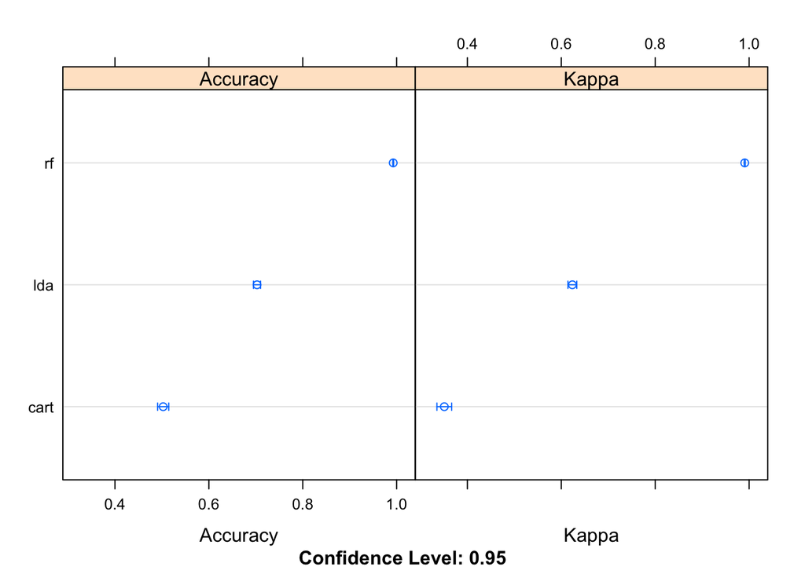

```r
# compare accuracy of models
dotplot(results)
```

### CONCLUSION

We can see that our Random Forest model is the best one to use so we’ll use it with our test dataset to predict our end result.

These predictions are used to answer the “Course Project Prediction Quiz”.

```r
final.test <- predict(fit.rf,newdata=test2)
print(final.test)
```

```
##  [1] B A B A A E D B A A B C B A E E A B B B
## Levels: A B C D E
```